# An Introduction to `CNVreg` Package to Perform Copy Number Variant Association Analysis with Penalied Regression

```r
# load the package
library("CNVreg")
```

### Introduction

The *CNVreg* package provides functions to perform copy number variants (CNV) association analysis with penalized regression model.

This package converts CNVs over a genomic region as a piecewise constant curve to capture the dosage and length of CNVs. The association analysis is then evaluated by regressing outcome traits on all CNV fragments in the region while adjusting for covariates. The corresponding CNV effects are obtained at each genome position. The penalized regression model with Lasso and weighted fusion penalties would perform variable selection and encourage adjacent CNVs to share similar effect size.

This package has 3 main functions:

- `prep()`: Data preprocessing and format conversion – required to prepare data for analysis.
- `cvfit_WTSMTH()`: Model fitting and effect estimate with cross-validation(CV). The CV procedure is to tune an optimal model by selecting the best pair of candidate tuning parameters.
- `fit_WTSMTH()`: Model fitting and effect estimate with a given pair of tuning parameters.

All functions use an example data included in the `CNVreg` package.

### Data

The `CNVCOVY` dataset included in this package contains a small sample of data for demonstration purposes. It has 4 separate data files: copy number variants data in `CNV`, covariate data in `Cov`, and outcome traits `Y_QT` (quantitative) and `Y_BT`(Binary).

- `CNV`: A data frame describing CNV data in PLINK format with 5 variables `ID`, `CHR`, `BP1`, `BP2`, and `TYPE`.
- `Cov`: A data frame with 3 variables: `ID`, `Sex`, and `Age`.
- `Y_QT` and `Y_BT`: each is a data frame for outcome traits. `Y_QT` contains a quantitative trait. `Y_BT` contains a binary trait. Both have 2 variables: `ID` and `Y`.

Here is how you can load and view the summary of the datasets:

```r
# load the example dataset
data("CNVCOVY", package = "CNVreg")
```

**Click to see summary information of each object loaded**

#### Toy Datasets

##### CNV

```r
# view the dataset
summary(CNV)
```

```
#>       ID                 CHR         BP1                 BP2
#>  Length:2680        Min.   :1   Min.   :118956400   Min.   :118956600
#>  Class :character   1st Qu.:1   1st Qu.:175325200   1st Qu.:175325800
#>  Mode  :character   Median :1   Median :203709300   Median :203709400
#>                     Mean   :1   Mean   :191999781   Mean   :192000245
#>                     3rd Qu.:1   3rd Qu.:229563000   3rd Qu.:229564400
#>                     Max.   :1   Max.   :238592100   Max.   :238593100
#>       TYPE
#>  Min.   :0.0000
#>  1st Qu.:1.0000
#>  Median :1.0000
#>  Mean   :0.9828
#>  3rd Qu.:1.0000
#>  Max.   :3.0000
```

##### COV

```r
# view the dataset
summary(Cov)
```

```
#>       ID                 Sex              Age
#>  Length:900         Min.   :0.0000   Min.   :50.00
#>  Class :character   1st Qu.:0.0000   1st Qu.:59.00
#>  Mode  :character   Median :1.0000   Median :70.00
#>                     Mean   :0.5011   Mean   :69.82
#>                     3rd Qu.:1.0000   3rd Qu.:80.00
#>                     Max.   :1.0000   Max.   :89.00
```

##### Y_QT

```r
# view the dataset
summary(Y_QT)
```

```
#>       ID                  Y
#>  Length:900         Min.   :-4.8950
#>  Class :character   1st Qu.:-2.3411
#>  Mode  :character   Median :-1.3730
#>                     Mean   : 0.4128
#>                     3rd Qu.: 3.5676
#>                     Max.   :16.7008
```

##### Y_BT

```r
# view the dataset
summary(Y_BT)
```

```
#>       ID                  Y
#>  Length:900         Min.   :0.0000
#>  Class :character   1st Qu.:0.0000
#>  Mode  :character   Median :0.0000
#>                     Mean   :0.4056
#>                     3rd Qu.:1.0000
#>                     Max.   :1.0000
```

Briefly, the dataset has the CNV (2680 records), covariates (`Sex` and `Age`), and outcome traits for 900 individuals.

### Data preprocessing

The `prep()` function converts an individual’s CNV events within a genomic region to fragments, and filters out rare events. It analyzes the adjacency relationship between CNV fragments and prepares different weight options for the penalized regression analysis.

#### Input of function `prep()`

The function `prep()` has 4 inputs.

- `CNV`: takes a data frame describing CNV in PLINK format with 5 variables: `ID`, `CHR`, `BP1`, `BP2`, and `TYPE`.
- `Y`: takes a data frame describing outcomes with 2 variables: `ID` and `Y`.
- `Z`: takes a data frame describing covariates, if `Z` is provided, one variable must be `ID`, other variables can be any covariates of interest.
- `rare.out`: takes a number in [0, 0.5). A default value is 0.05, which excludes CNVs with frequency < $5\%$

#### Output of function `prep()`

The output of the `prep()` function has a specially designed “WTsmth.data” format for easy application in the next step for CNV association analysis. It has 6 components.

- `design`: a matrix of the CNV fragments in n by p dimensions, where n is the number of samples and p is the total number of CNV fragments. Rownames are sample ID, and the order of rownames is the same as the rownames of the outcome file (`frag_data_QT$Y`).
- `Z`: a matrix of covariates with sample ID as rownames. The rownames are in the same order as in the outcome file (`frag_data_QT$Y`).
- `Y`: a matrix of 1 column with sample ID as rownames. The rownames are in the same order as in the CNV design matrix `frag_data_QT$design` and covariates `frag_data_QT$Z`.
- `weight.structure`: a matrix that describes the adjacency structure of CNV fragments. The matrix is sparse and most values are zero, while non-zero values represent two adjacent CNV fragments that are overlapped by at least one CNV event in the population.
- `weight.options`: we provide 6 different options of weights that encourage differential information sharing based on the relationship between adjacent CNV fragments. Equal weight `eql`, Cosine-similarity based weight `wcs`, Inverse frequency weight `wif`, and combining these 3 weights with the frequency (k) of any CNV events within each CNV-active region (“keql”, “kwcs”, and “kwif”). Refer to the user manual for more information.
- `CNVR.info` summarizes the positions of all CNV fragments and their adjacency information. Each row represents a CNV fragment and the fragment names match the column names in `frag_data_QT$design`.

#### Application of `prep()` function

Here is how you can use the `prep()` function to preprocess `CNV`, `Cov` and an outcome trait. The outcome trait can be a continuous trait `Y_QT` or a binary trait `Y_BT`. The command syntax of the `prep()` function is the same for continuous and binary outcomes. We showcase two application examples, which will be used in the next step to illustrate CNV association analysis with a continuous outcome and a binary outcome.

##### Application 1: Process `CNV`, `Cov`, and a continuous trait `Y_QT`

```r
# data preprocessing for a quantitative(continuous) outcome Y_QT
frag_data_QT <- prep(CNV = CNV, Y = Y_QT, Z = Cov, rare.out = 0.05)
```

**Click to see the summary details of the output `frag_data_QT`**

```r
# Format of `prep()` funtion output
 str(frag_data_QT)
```

```
#> List of 6
#>  $ design          :Formal class 'dgCMatrix' [package "Matrix"] with 6 slots
#>   .. ..@ i       : int [1:5552] 9 13 15 21 24 38 55 57 62 66 ...
#>   .. ..@ p       : int [1:20] 0 177 320 465 608 752 1189 1914 2517 3081 ...
#>   .. ..@ Dim     : int [1:2] 900 19
#>   .. ..@ Dimnames:List of 2
#>   .. .. ..$ : chr [1:900] "U1" "U10" "U100" "U101" ...
#>   .. .. ..$ : chr [1:19] "del1" "del3" "del4" "del5" ...
#>   .. ..@ x       : num [1:5552] 200 200 200 200 200 200 200 200 200 200 ...
#>   .. ..@ factors : list()
#>  $ Z               :Formal class 'dgCMatrix' [package "Matrix"] with 6 slots
#>   .. ..@ i       : int [1:1351] 3 4 5 6 7 9 10 12 14 15 ...
#>   .. ..@ p       : int [1:3] 0 451 1351
#>   .. ..@ Dim     : int [1:2] 900 2
#>   .. ..@ Dimnames:List of 2
#>   .. .. ..$ : chr [1:900] "U1" "U10" "U100" "U101" ...
#>   .. .. ..$ : chr [1:2] "Sex" "Age"
#>   .. ..@ x       : num [1:1351] 1 1 1 1 1 1 1 1 1 1 ...
#>   .. ..@ factors : list()
#>  $ Y               : Named num [1:900] -1.816 -0.321 -2.624 -0.688 3.288 ...
#>   ..- attr(*, "names")= chr [1:900] "U1" "U10" "U100" "U101" ...
#>  $ weight.structure:Formal class 'dgCMatrix' [package "Matrix"] with 6 slots
#>   .. ..@ i       : int [1:22] 1 1 2 2 3 3 4 4 5 5 ...
#>   .. ..@ p       : int [1:20] 0 0 1 3 5 6 7 9 11 12 ...
#>   .. ..@ Dim     : int [1:2] 15 19
#>   .. ..@ Dimnames:List of 2
#>   .. .. ..$ : NULL
#>   .. .. ..$ : NULL
#>   .. ..@ x       : num [1:22] -1 1 -1 1 -1 1 -1 1 -1 1 ...
#>   .. ..@ factors : list()
#>  $ weight.options  : num [1:6, 1:15] 0 0 0 0 0 ...
#>   ..- attr(*, "dimnames")=List of 2
#>   .. ..$ : chr [1:6] "eql" "keql" "wcs" "kwcs" ...
#>   .. ..$ : NULL
#>  $ CNVR.info       :'data.frame':    19 obs. of  7 variables:
#>   ..$ grid.id  : int [1:19] 1 3 4 5 6 8 9 10 11 13 ...
#>   ..$ CNV.id   : int [1:19] 1 2 2 2 2 3 3 3 3 4 ...
#>   ..$ freq     : int [1:19] 177 143 145 143 144 437 725 603 564 640 ...
#>   ..$ CHR      : int [1:19] 1 1 1 1 1 1 1 1 1 1 ...
#>   ..$ CNV.start: num [1:19] 1.19e+08 1.21e+08 1.21e+08 1.21e+08 1.21e+08 ...
#>   ..$ CNV.end  : num [1:19] 1.19e+08 1.21e+08 1.21e+08 1.21e+08 1.21e+08 ...
#>   ..$ deldup   : chr [1:19] "del" "del" "del" "del" ...
#>  - attr(*, "class")= chr "WTsmth.data"
```

##### Application 2: Process `CNV`, `Cov`, and a binary trait `Y_BT`

```r
# data preprocessing with a binary trait
frag_data_BT <- prep(CNV = CNV, Y = Y_BT, Z = Cov, rare.out = 0.05)
```

There is an alternative way to prepare data when performing CNV association analysis with the same set of CNVs for multiple outcome traits. Since we have the same `CNV` data, `Cov` data, and a different outcome trait `Y_BT`, we can manually format `Y_BT` to match the format in `frag_data_QT$Y`.

**Click to see alternative usage.**

```r
## copy frag_data_QT
frag_data_BT <- frag_data_QT

### replace Y with Y_BT in the correct format: ordered named vector
### order the sample in Y_BT as in frag_data_QT$Y
rownames(Y_BT) <- Y_BT$ID

frag_data_BT$Y <- Y_BT[names(frag_data_QT$Y), "Y"] |> drop()
names(frag_data_QT$Y) <- rownames(frag_data_QT$Y)
```

Directly replace `frag_data_QT$Z` is also possible, keep in mind to use the correct variable names and sample ID order.

### Analysis with cross-validation (CV)

The `cvfit_WTSMTH()` function analyzes the association between a continuous/binary trait value and `CNV` while adjusting for the covariates `Cov`.

#### CNV association analysis for a continuous outcome

We already have `frag_data_QT` prepared in the `prep()` step. We can fit a model to perform CNV association analysis for a continuous outcome using CV to fine-tune tuning parameters and fit an optimal model with the selected parameters.

```r
  QT_TUNE <- withr::with_seed(
    12345,
    cvfit_WTSMTH(data = frag_data_QT,
                 lambda1 = seq(-8, -3, 1),
                 lambda2 = seq(12, 25, 2),
                 weight = "eql",
                 family = "gaussian",
                 cv.control = list(n.fold = 5L,
                                   n.core = 1L,
                                   stratified = FALSE),
                 verbose = FALSE))
```

##### Input of function `cvfit_WTSMTH()`

- `data`: The `cvfit_WTSMTH()` function takes a `data` in `WTsmth.data` format, which is the output of `prep()` function, as one of the major inputs, for example, `frag_data_QT` prepared for the continuous trait and `frag_data_BT` prepared for the binary trait.
- `lambda1` and `lambda2`: take the candidate tuning parameters that control variable selection (`lambda1`) and effect smoothness (`lambda2`). Provided values will be transformed to 2^(`lambda1`) and 2^(`lambda2`). We provide default values for both vectors. The user can customize the range and step_size of the candidate tuning parameters. In most cases, the user will need to run the function more than one time to adjust the range and step_size of tuning parameters to locate to a reasonable range according to the previous round of model fitting.
- `weight`: it has six different options as described earlier. Since we only have a small dataset, varying the `weight` options will not have much influence on the model fitting results. In real CNV data with different similarity patterns and CNV frequencies, varying the `weight` option are expected to have different effects.
- `family`: has two options: `gaussian` for a continuous outcome, and `binomial` for a binary outcome.
- `cv.control`: This function also supports parallel computing and change of n-folds in CV by adjusting the `cv.control` list.
  - `n.fold` controls the number of folds used in CV.
  - `n.core` controls the the number of cores used in parallel computing.
  - `stratified` only has control for a binary outcome. We will skip it here and describe it in the binary section.
- `verbose`: If choose `verbose` = TRUE, it will print a message about where the program is currently working on.

##### Output of function `cvfit_WTSMTH()`

The output of the `cvfit_WTSMTH()` function is a list object containing 3 elements: `Loss`, `lambda.selected`, and `coef`.

- `Loss`

  The `Loss` keeps track of the average validation loss in CV for each pair of candidate tuning parameters $\lambda_{1}$ and $\lambda_{2}$. In the following table, the minimum loss is highlighted and the corresponding $\lambda_{1}$ and $\lambda_{2}$ values are selected to fit a final model.

  In this simulated data, the variation of loss for different $\lambda_{2}$ with the same $\lambda_{1}$ is not very large. One reason is that $\lambda_{2}$ controls the effect smoothness between adjacent CNVs, and the simulation data only has a small number of CNVs in adjacent that share effects to other CNVs. The effect of changing $\lambda_{2}$ seems not prominence in this case. When we have more CNVs in adjacent and share effects, it should have larger variance across $\lambda_{2}$.

Average loss for each pair of candidate tuning parameters

| Lambda2 | Lambda 1 -8 | Lambda 1 -7 | Lambda 1 -6 | Lambda 1 -5 | Lambda 1 -4 | Lambda 1 -3 |
| --- | --- | --- | --- | --- | --- | --- |
| 12 | 1.004534 | 1.003579 | 0.998444 | 0.993686 | 0.997349 | 1.02374 |
| 14 | 1.008237 | 1.007236 | 1.002091 | 0.997715 | 1.002085 | 1.02904 |
| 16 | 1.005668 | 1.004547 | 0.999433 | 0.995208 | 0.999796 | 1.02829 |
| 18 | 1.001295 | 1.000519 | 0.995631 | 0.991565 | 0.996885 | 1.02515 |
| 20 | 0.999942 | 0.998498 | 0.993783 | 0.990641 | 0.996864 | 1.02829 |
| 22 | 0.998218 | 0.996816 | 0.992557 | 0.991599 | 1.000824 | 1.04408 |
| 24 | 0.998674 | 0.995685 | 0.992663 | 0.995447 | 1.015663 | 1.10326 |

- `selected.lambda`

The `selected.lambda` is the optimal tuning parameters from the candidate lists that has the lowest loss, which can be confirmed with the `Loss` table.

```r
# selected optimal tuning parameters with minimum loss
 QT_TUNE$selected.lambda
```

```
#> [1] -5 20
```

- `coef`

The `coef` shows the estimated beta coefficients at the selected tuning parameters. It has `(intercept)`, CNV fragments (with detailed positions/type information), and covariate effects. In this small example, we can print all coefficient estimate, but you can modify the code to show only non-zero ones.

Here lists the coefficients for `(Intercept)` and covariates. The characteristics for CNV (CHR, CNV.start, CNV.end, and deldup) are left as `NA`s intentionally in the original output. Here we only show the effect estimate.

```r
##coefficients of intercept and covariates
QT_TUNE$coef[c(1, 21:22), c("Vnames", "coef") ]
```

```
#>         Vnames     coef
#> 1  (Intercept) -1.99855
#> 21         Sex  0.00000
#> 22         Age  0.00000
```

Here lists the coefficients for CNVs and the corresponding plots.

We highlight the regions with adjacent CNVs. From the coefficient estimates, the model selects several non-zero CNVs (data points). Among the data points, the red ones have stronger effect than the black dots. The black dots are likely noise.

We also zoom in on two highlighted regions with strong signals and adjacent CNVs to show the effect smoothness within the regions.

The results illustrate the variable selection and effect smoothness of the penalized regression method for CNV association analysis.

**Click to see CNV coefficient estimates.**

```r
# estimated coefficents for CNV
QT_TUNE$coef[2:20, ]
```

```
#>    Vnames CHR CNV.start   CNV.end deldup          coef
#> 2    del1   1 118956400 118956600    del  0.0000000000
#> 3    del3   1 121299300 121299500    del  0.0048659084
#> 4    del4   1 121299500 121299700    del  0.0046967844
#> 5    del5   1 121299700 121299800    del  0.0046911466
#> 6    del6   1 121299800 121300400    del  0.0051456642
#> 7    del8   1 175325200 175325400    del -0.0001740566
#> 8    del9   1 175325400 175325500    del  0.0000000000
#> 9   del10   1 175325500 175325600    del  0.0000000000
#> 10  del11   1 175325600 175325800    del  0.0000000000
#> 11  del13   1 203709300 203709400    del -0.0002731880
#> 12  del17   1 229563000 229563200    del  0.0042092931
#> 13  del18   1 229563200 229563500    del  0.0046547584
#> 14  del19   1 229563500 229563900    del  0.0048148656
#> 15  del20   1 229563900 229564400    del  0.0057050100
#> 16  del23   1 235735000 235735100    del  0.0000000000
#> 17  del25   1 238591800 238592100    del  0.0000000000
#> 18  del26   1 238592100 238592900    del  0.0000000000
#> 19  del27   1 238592900 238593100    del  0.0000000000
#> 20  dup15   1 212455200 212455300    dup  0.0000000000
```

```r
# non-zero coefficients
# QT_TUNE$coef[which(abs(QT_TUNE$coef$coef)>0), ]
```

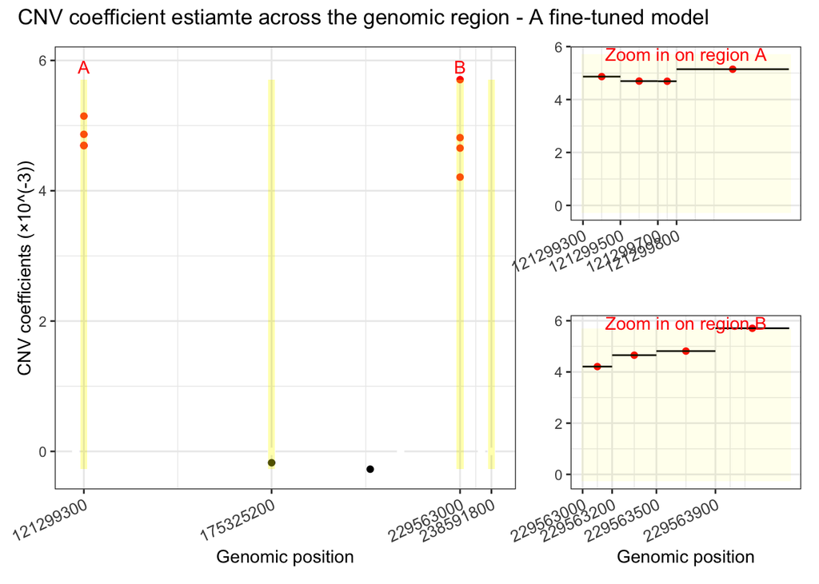

#### CNV association analysis for a binary outcome

```r
BT_TUNE <- withr::with_seed(
  12345,
  cvfit_WTSMTH(frag_data_BT,
               lambda1 = seq(-5.25, -4.75, 0.25),
               lambda2 = seq(2,  8, 2),
               weight = "eql",
               family = "binomial",
               cv.control = list(n.fold = 5L,
                                 n.core = 1L,
                                 stratified = FALSE),
               iter.control = list(max.iter = 8L,
                                   tol.beta = 10^(-3),
                                   tol.loss = 10^(-6)),
               verbose = FALSE))
```

##### Input of function `cvfit_WTSMTH()`

The CNV association analysis for a bianry outcome has similar inputs as for a continuous outcome. The differences are:

- The output `frag_data_BT` from the `prep()` step has a binary trait `Y_BT` ready for CNV association analysis with a binary outcome.
- Choose `family` = “binomial” for a binary trait.
- There are a few more options specifically designed for the binary trait.
  - `stratified` within the `cv.control` list: If one category of the binary outcome is considered “rare”, `stratified` = TRUE is recommended to make sure the data splits are having the same proportion of cases and controls in each fold.
  - `iter.control`: For a binary outcome, we can also adjust the `iter.control` list with desired threshold that is deemed converged for coefficient estimate of a binary outcome. Refer to the user manual for more details.

##### Output of function `cvfit_WTSMTH()`

The output of the `cvfit_WTSMTH()` function has the same list object containing 3 elements: `Loss`, `lambda.selected`, and `coef`.

- `Loss`

`The`Loss` keeps track of the average validation loss in CV for each pair of candidate tuning parameters $\lambda_{1}$ and $\lambda_{2}$. In the following table, the minimum loss is highlighted and the corresponding $\lambda_{1}$ and $\lambda_{2}$ values are selected to fit a final model.

Since the regression process for a binary trait takes longer time to converge, here we only use a short list of candidate tuning parameters for illustration purpose.

Average loss for each pair of candidate tuning parameters

| Lambda2 | Lambda 1 -5.25 | Lambda 1 -5 | Lambda 1 -4.75 |
| --- | --- | --- | --- |
| 2 | 0.281147 | 0.280297 | 0.279914 |
| 4 | 0.279573 | 0.278999 | 0.278696 |
| 6 | 0.278115 | 0.277811 | 0.277819 |
| 8 | 0.278173 | 0.278394 | 0.279038 |

- `selected.lambda`

The `selected.lambda` are the optimal tuning parameters from the candidate lists that has the lowest loss, which can be confirmed with the `Loss` table.

```r
# selected optimal tuning parameters with minimum loss
 BT_TUNE$selected.lambda
```

```
#> [1] -5  6
```

- `coef`

The estimated beta coefficients `coef` at the selected tuning parameters. It has `(intercept)`, CNV fragments (with detailed positions/type information), and covariate effects. In this small data example, we can print all coefficient estimate, but you can modify the code to show non-zero ones or the first few ones.

Here lists the coefficients for `(Intercept)` and covariates.

```r
BT_TUNE$coef[c(1, 21:22), c("Vnames", "coef") ]
```

```
#>         Vnames      coef
#> 1  (Intercept) -1.953386
#> 21         Sex  0.000000
#> 22         Age  0.000000
```

Here lists the coefficients for CNVs and the corresponding plots.

**Click to see CNV coefficient estimates.**

```r
BT_TUNE$coef[2:20, ]
```

```
#>    Vnames CHR CNV.start   CNV.end deldup         coef
#> 2    del1   1 118956400 118956600    del 0.000000e+00
#> 3    del3   1 121299300 121299500    del 2.879470e-03
#> 4    del4   1 121299500 121299700    del 3.530621e-03
#> 5    del5   1 121299700 121299800    del 3.023385e-03
#> 6    del6   1 121299800 121300400    del 4.925100e-03
#> 7    del8   1 175325200 175325400    del 0.000000e+00
#> 8    del9   1 175325400 175325500    del 0.000000e+00
#> 9   del10   1 175325500 175325600    del 0.000000e+00
#> 10  del11   1 175325600 175325800    del 4.010457e-05
#> 11  del13   1 203709300 203709400    del 0.000000e+00
#> 12  del17   1 229563000 229563200    del 1.650097e-03
#> 13  del18   1 229563200 229563500    del 2.782514e-03
#> 14  del19   1 229563500 229563900    del 4.412988e-03
#> 15  del20   1 229563900 229564400    del 5.905259e-03
#> 16  del23   1 235735000 235735100    del 0.000000e+00
#> 17  del25   1 238591800 238592100    del 0.000000e+00
#> 18  del26   1 238592100 238592900    del 0.000000e+00
#> 19  del27   1 238592900 238593100    del 0.000000e+00
#> 20  dup15   1 212455200 212455300    dup 0.000000e+00
```

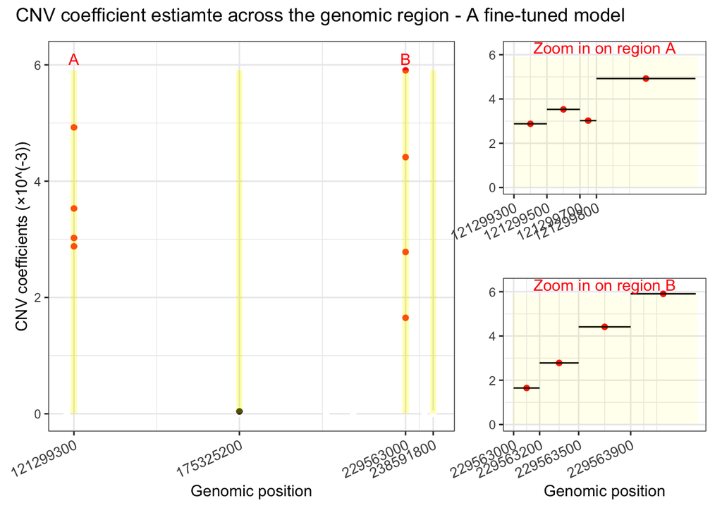

### Analysis with fixed tuning parameters

The user can use the function `fit_WTSMTH()` to reproduce the regression result with the selected pair of parameters.

The `fit_WTSMTH()` function and the `cvfit_WTSMTH()` function uses the same analytical methods to perform CNV association analysis with penalized regression. Unlike the `cvfit_WTSMTH()` function that will fine-tune the parameters and select the optimal combination of $\lambda_{1}$ and $\lambda_{2}$ from a series of candidates, the `fit_WTSMTH()` function takes a user-specified value for $\lambda_{1}$ and $\lambda_{2}$ and estimate the coefficients for the given pair of parameters. Although, it is much faster to perform `fit_WTSMTH()`, we do recommend the user to stick with the parameter tuning procedure with `cvfit_WTSMTH()` and find the best parameters and the corresponding model.

If we already have a selected the best pair of parameters $\lambda_{1}$ and $\lambda_{2}$ from the CV procedure, we can refit the regression model, and the coefficient estimate is the same as in the fine-tuned model.

```r
# we know the optimal tuning parameters and directly apply it to reproduce the analysis for a continuous outcome.
QT_fit <- fit_WTSMTH(frag_data_QT,
                      lambda1 = -5,
                      lambda2 = 20,
                      weight="eql",
                      family="gaussian")
```

#### Input of function `fit_WTSMTH()`

The input variables of function `fit_WTSMTH()` is similar to that of `cvfit_WTSMTH()`.

- `data`: it also takes `data` in `WTsmth.data` format as prepared in the `prep()` step.
- `lambda1` and `lambda2`: each takes one numeric value. Provided values will be transformed to 2^(`lambda1`) and 2^(`lambda2`).
- `weight`: it takes one of the options from {`eql`, `keql`, `wcs`, `kwcs`, `wif`, `kwif`} as mentioned earlier.
- `family`: it takes `gaussian` for a continuous outcome and `binomial` for a binary outcome.
- `iter.control`: for a binary outcome, `iter.control` controls iterative coefficient estimate procedure as described earlier.

#### Output of `fit_WTSMTH()`

Refit the model with the selected pair of tuning parameters for a continuous outcome `Y_QT`. The coefficient estimate from `fit_WTSMTH()` is the same as the coefficient estimate of `cvfit_WTSMTH()`.

Here lists the coefficients for `(Intercept)` and covariates.

```r
QT_fit[c(1, 21:22), c("Vnames", "coef") ]
```

```
#>         Vnames     coef
#> 1  (Intercept) -1.99855
#> 21         Sex  0.00000
#> 22         Age  0.00000
```

Here lists the coefficients for CNVs and the corresponding plots.

**Click to see CNV coefficient estimates.**

```r
QT_fit[2:20, ]
```

```
#>    Vnames CHR CNV.start   CNV.end deldup          coef
#> 2    del1   1 118956400 118956600    del  0.0000000000
#> 3    del3   1 121299300 121299500    del  0.0048659084
#> 4    del4   1 121299500 121299700    del  0.0046967844
#> 5    del5   1 121299700 121299800    del  0.0046911466
#> 6    del6   1 121299800 121300400    del  0.0051456642
#> 7    del8   1 175325200 175325400    del -0.0001740566
#> 8    del9   1 175325400 175325500    del  0.0000000000
#> 9   del10   1 175325500 175325600    del  0.0000000000
#> 10  del11   1 175325600 175325800    del  0.0000000000
#> 11  del13   1 203709300 203709400    del -0.0002731880
#> 12  del17   1 229563000 229563200    del  0.0042092931
#> 13  del18   1 229563200 229563500    del  0.0046547584
#> 14  del19   1 229563500 229563900    del  0.0048148656
#> 15  del20   1 229563900 229564400    del  0.0057050100
#> 16  del23   1 235735000 235735100    del  0.0000000000
#> 17  del25   1 238591800 238592100    del  0.0000000000
#> 18  del26   1 238592100 238592900    del  0.0000000000
#> 19  del27   1 238592900 238593100    del  0.0000000000
#> 20  dup15   1 212455200 212455300    dup  0.0000000000
```

However, if we choose a random pair of tuning parameters, the function will not have optimal variable selection and effect smoothness performance.

In summary, the `cvfit_WTSMTH()` function is recommended for model fitting with CV. `fit_WTSMTH()` can be used for testing purpose or to reproduce the result.